# Terceiro trabalho prático de Introdução à Computação Visual:

# Gráficos de acertos

Abaixo temos o gráfico de minimo de caracteres corretamente reconhecidos pelo modelo para treino, validação, e teste.

Note que o conjunto de dados de teste só foi utilizado nesta etapa, depois de o trabalho inteiro estar pronto e escrito, então carregamos e preparamos de seus dados somente nessa parte do notebook.

### Treino

```
Taxas de reconhecimento:  [1.       0.99975  0.99975  0.99975  0.99925  0.98825  0.884125]
```

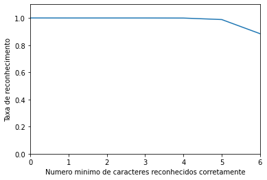

```python
# Treino
correct_treino = np.zeros(7, dtype = np.float64)
preds = model.predict(X_train_isol_chars)
examples = np.full(7,-1)
for i in range(8000):
  pred_train = preds[i*6:i*6+6]
  pred_chars = np.zeros(6)
  for j in range(6):
    pred_chars[j] = np.argmax(pred_train[j])
  ncorrect = (pred_chars == y_train_isol_chars[i*6:i*6+6]).sum()
  correct_treino[ncorrect] += 1
  if examples[ncorrect] == -1:
    examples[ncorrect] = i
for i in [5,4,3,2,1,0]:
  correct_treino[i] += correct_treino[i+1]
for i in [6,5,4,3,2,1,0]:
  correct_treino[i] /= correct_treino[0]

plt.xlabel("Numero minimo de caracteres reconhecidos corretamente")
plt.ylabel("Taxa de reconhecimento")
plt.xlim([0,6])
plt.ylim([0,1.1])
plt.plot(correct_treino)
print("Taxas de reconhecimento: ", correct_treino)
```

Abaixo temos exemplos em que a identificação foi correta em 0, 3, 4, 5 e 6 caracteres:

```
Esperado: EG22C9
Previsto: QMIJVC
```

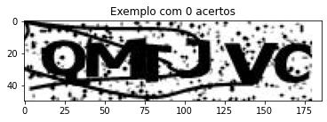

```
Esperado: ORQOOK
Previsto: 0RQ00K
```

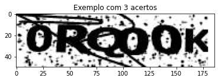

```
Esperado: OLODP1
Previsto: 0L0DP1
```

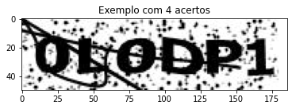

```
Esperado: N1O1EH
Previsto: N101EH
```

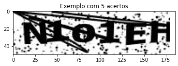

```
Esperado: RNINIC
Previsto: RNINIC
```

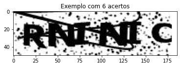

```python
for i in range(7):
  if examples[i] == -1:
    continue # Nenhum caso com exatamente essa quantidade de acertos
  plt.title("Exemplo com "+str(i)+" acertos")
  pred = preds[examples[i]*6:examples[i]*6+6]
  stri = ""
  for charn in pred:
    stri += num_to_char(np.argmax(charn))
  print("Esperado: "+y_train[examples[i]][:-1])
  print("Previsto: "+stri)
  plt.imshow(X_train_raw[examples[i]], cmap = "gray")
  plt.show()
  plt.close()
  print()
```

### Validação

```
Taxas de reconhecimento:  [1.    1.    1.    1.    0.998 0.986 0.855]
```

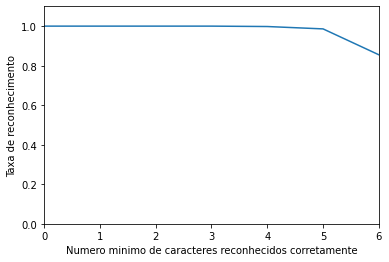

```python
# Validacao
correct_validacao = np.zeros(7, dtype = np.float64)
preds = model.predict(X_val_isol_chars)
examples = np.full(7,-1)
for i in range(1000):
  pred_val = preds[i*6:i*6+6]
  pred_chars = np.zeros(6)
  for j in range(6):
    pred_chars[j] = np.argmax(pred_val[j])
  ncorrect = (pred_chars == y_val_isol_chars[i*6:i*6+6]).sum()
  correct_validacao[ncorrect] += 1
  if examples[ncorrect] == -1:
    examples[ncorrect] = i
for i in [5,4,3,2,1,0]:
  correct_validacao[i] += correct_validacao[i+1]
for i in [6,5,4,3,2,1,0]:
  correct_validacao[i] /= correct_validacao[0]

plt.xlabel("Numero minimo de caracteres reconhecidos corretamente")
plt.ylabel("Taxa de reconhecimento")
plt.xlim([0,6])
plt.ylim([0,1.1])
plt.plot(correct_validacao)
print("Taxas de reconhecimento: ", correct_validacao)
```

Abaixo temos exemplos em que a identificação foi correta em 3, 4, 5 e 6 caracteres:

```
Esperado: WW9VOJ
Previsto: VWR7OJ
```

[figure not shown]

```
Esperado: SICNS5
Previsto: SION55
```

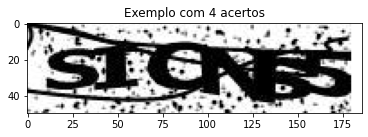

```
Esperado: R7KEMX
Previsto: R7KEM5
```

[figure not shown]

```
Esperado: HYR3GP
Previsto: HYR3GP
```

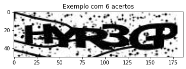

```python
for i in range(7):
  if examples[i] == -1:
    continue # Nenhum caso com exatamente essa quantidade de acertos
  plt.title("Exemplo com "+str(i)+" acertos")
  pred = preds[examples[i]*6:examples[i]*6+6]
  stri = ""
  for charn in pred:
    stri += num_to_char(np.argmax(charn))
  print("Esperado: "+y_val[examples[i]][:-1])
  print("Previsto: "+stri)
  plt.imshow(X_val_raw[examples[i]], cmap = "gray")
  plt.show()
  plt.close()
  print()
```

### Teste

Carregando dados do teste:

```python
# Teste
X_test_raw = []
for name, dirs, files in os.walk("dados/CAPTCHA-10k/teste"):
  files = np.sort(files)
  for image_file in files:
    img = load_img(
      "dados/CAPTCHA-10k/teste/"+image_file,
      color_mode="grayscale",
      target_size=None,
    )
    X_test_raw.append(np.array(img))
X_test_raw = np.array(X_test_raw)
y_test = all_labels[9000:10000]
```

Adicionando Padding do teste:

```python
padding_tests = np.full((X_test_raw.shape[0],X_test_raw.shape[1],X_test_raw.shape[2]+6),255)
print(X_test_raw.shape)
padding_tests[:,:,:-6] = X_test_raw
print(padding_tests.shape)
X_test_raw = padding_tests
```

```
(1000, 50, 180)
(1000, 50, 186)
```

Setando profundidade das imagens de teste para 1:

```python
# Setando profundidade das imagens para 1
X_test = X_test_raw.reshape(X_test_raw.shape[0], 50, 186, 1)
print(X_test.shape)
print(y_test.shape)
```

```
(1000, 50, 186, 1)
(1000,)
```

Normalizando imagens de teste:

```python
# Normalizando imagens para ficar entre 0,1
X_test_norm = X_test.astype('float32')
X_test_norm /= 255
```

Separando caracteres do teste:

```python
# Criando teste com caracteres isolados
X_test_isol_chars = []
y_test_isol_chars = []
for i in range(len(X_test_norm)):
  for char in [0,1,2,3,4,5]:
    X_test_isol_chars.append(X_test_norm[i][10:45,ch_separation[char][0]:ch_separation[char][1]])
    y_test_isol_chars.append(char_to_num(ord(y_test[i][char])))
X_test_isol_chars = np.array(X_test_isol_chars)
y_test_isol_chars = np.array(y_test_isol_chars)
```

Categorizando as letras do ground_truth:

```python
# Categorizando letras
y_test_cat = np_utils.to_categorical(y_test_isol_chars, 36)
```

Avaliando modelo no teste:

```python
score = model.evaluate(X_test_isol_chars, y_test_cat, verbose=1)
print(score)
```

```
[0.1417093425989151, 0.9704999923706055]
```

Gráfico do teste:

```
Taxas de reconhecimento:  [1.    1.    1.    1.    0.999 0.987 0.837]
```

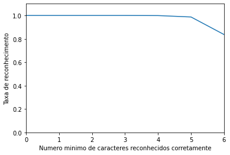

```python
# Teste
correct_teste = np.zeros(7, dtype = np.float64)
preds = model.predict(X_test_isol_chars)
examples = np.full(7,-1)
for i in range(1000):
  pred_test = preds[i*6:i*6+6]
  pred_chars = np.zeros(6)
  for j in range(6):
    pred_chars[j] = np.argmax(pred_test[j])
  ncorrect = (pred_chars == y_test_isol_chars[i*6:i*6+6]).sum()
  correct_teste[ncorrect] += 1
  if examples[ncorrect] == -1:
    examples[ncorrect] = i
for i in [5,4,3,2,1,0]:
  correct_teste[i] += correct_teste[i+1]
for i in [6,5,4,3,2,1,0]:
  correct_teste[i] /= correct_teste[0]

plt.xlabel("Numero minimo de caracteres reconhecidos corretamente")
plt.ylabel("Taxa de reconhecimento")
plt.xlim([0,6])
plt.ylim([0,1.1])
plt.plot(correct_teste)
print("Taxas de reconhecimento: ", correct_teste)
```

Exemplos com 3, 4, 5 e 6 acertos:

[output not shown]

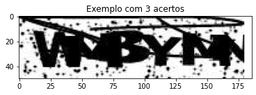

```
Esperado: FVVTLX
Previsto: FW7TLX
```

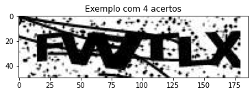

```
Esperado: 615OUK
Previsto: 615OUX
```

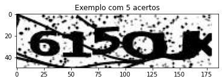

```
Esperado: JW4CZF
Previsto: JW4CZF
```

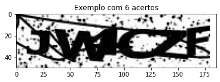

```python
for i in range(7):
  if examples[i] == -1:
    continue # Nenhum caso com exatamente essa quantidade de acertos
  plt.title("Exemplo com "+str(i)+" acertos")
  pred = preds[examples[i]*6:examples[i]*6+6]
  stri = ""
  for charn in pred:
    stri += num_to_char(np.argmax(charn))
  print("Esperado: "+y_test[examples[i]][:-1])
  print("Previsto: "+stri)
  plt.imshow(X_test_raw[examples[i]], cmap = "gray")
  plt.show()
  plt.close()
  print()
```

# Tentativas falhas:

Antes de chegar ao modelo utilizado, tentei várias outras formas de resolver o problema. Listei algumas delas abaixo e o que pode ser um problema de cada uma:

- Mudanças na arquitetura:

Tentei inicialmente com menos camadas convolucionais, mas o resultado obtido foi mais confusão nos caracteres. Por exemplo, com apenas uma camada a rede confundia muito "5" com "S", apesar de serem facilmente distinguíveis para o olho humano. Acredito que faltava um refinamento maior nas features, e consegui alcançar um bom resultado depois de três camadas convolucionais.

- Treinar caracteres separadamente:

Tentei também treinar uma rede especializada em separar "O" de "não-O", e caso ela diga que o caractere não é "O", usar a rede principal pra classificar. A idéia era que a rede especializada em encontrar "O" ia diminuir a quantidade de erros nesse caractere, que foi de longe o mais problemático. Tentei fazer o treinamento dessa outra rede com todos os caracteres, e também com uma quandiade reduzida dos caracteres para o treino possuir a mesma quantia de "O" e "não-O", mas nenhuma das duas opções trouxe melhorias significativas (a melhor melhoria foi de menos que 0.1% de acurácia na validação).

Ainda seguindo esse raciocínio, tentei treinar uma rede pra outros caracteres problemáticos além do "O" (como "W" e "S", que estavam com mais erros nas primeiras tentativas), mas além do tempo de treino se tornar muito extenso, os erros só aumentaram. Portanto, desisti dessa linha de tentativas.

- Treinar posições separadamente:

Por fim, tentei também treinar uma rede para cada posição do CAPTCHA (uma para reconhecer o primeiro caractere, outra para o segundo, etc.), partindo da observação que o último caractere é bem diferente dos outros, sendo cortado em muitos dos captchas. No entanto, isso também só piorou o resultado final.

Eu acredito que isso ocorreu por não haver dados o bastante para treinar uma rede como a atual por posição, cada um com a quantidade de pesos da que temos agora. E não consegui reduzir a quantidade de pesos utilizada na versão atual sem perder acurácia, nem modificar o tamanho do batch e quantidade de épocas de forma que melhorasse o resultado.